# Prosper Loan Data Exploration

## Examining the structure of the dataset

The dataset is quite robust, containing 113,937 rows and 81 variables. This is a considerable amount of variables and inlcudes detailed information about the investor, the borrower as well as the loan itself.

```
## 'data.frame':    113937 obs. of  81 variables:
##  $ ListingKey                         : Factor w/ 113066 levels "00003546482094282EF90E5",..: 7180 7193 6647 6669 6686 6689 6699 6706 6687 6687 ...
##  $ ListingNumber                      : int  193129 1209647 81716 658116 909464 1074836 750899 768193 1023355 1023355 ...
##  $ ListingCreationDate                : Factor w/ 113064 levels "2005-11-09 20:44:28.847000000",..: 14184 111894 6429 64760 85967 100310 72556 74019 97834 97834 ...
##  $ CreditGrade                        : Factor w/ 9 levels "","A","AA","B",..: 5 1 8 1 1 1 1 1 1 1 ...
##  $ Term                               : int  36 36 36 36 36 60 36 36 36 36 ...
##  $ LoanStatus                         : Factor w/ 12 levels "Cancelled","Chargedoff",..: 3 4 3 4 4 4 4 4 4 4 ...
##  $ ClosedDate                         : Factor w/ 2803 levels "","2005-11-25 00:00:00",..: 1138 1 1263 1 1 1 1 1 1 1 ...
##  $ BorrowerAPR                        : num  0.165 0.12 0.283 0.125 0.246 ...
##  $ BorrowerRate                       : num  0.158 0.092 0.275 0.0974 0.2085 ...
##  $ LenderYield                        : num  0.138 0.082 0.24 0.0874 0.1985 ...
##  $ EstimatedEffectiveYield            : num  NA 0.0796 NA 0.0849 0.1832 ...
##  $ EstimatedLoss                      : num  NA 0.0249 NA 0.0249 0.0925 ...
##  $ EstimatedReturn                    : num  NA 0.0547 NA 0.06 0.0907 ...
##  $ ProsperRating..numeric.            : int  NA 6 NA 6 3 5 2 4 7 7 ...
```

[output cut: 67 more lines]

As the dataset has so many variables, for the purpose of this report we shall focus only on a few select ones which will first be explored using univariate and summary analysis and then analysed in more detail in the bivariate and multivariate analysis sections.

Before we explore these variables, I will clean a few of the variables.

## Converting listing cateogry from numeric to factor.

# Univariate Plots Section

To get started, we will preform univariate analysis on a number of the variables to get a feel for the dataset and basic distributions of the key variables. A short descripton is also provided after each visual.

## Distribution of Loan Amounts

```
##    Min. 1st Qu.  Median    Mean 3rd Qu.    Max.
##    1000    4000    6500    8337   12000   35000
```

Minimum loan value appears to be $1,000 and the Max is $35,000. The median loan amount is $6,500. It appears that only 25% of the loans are above $12,000.

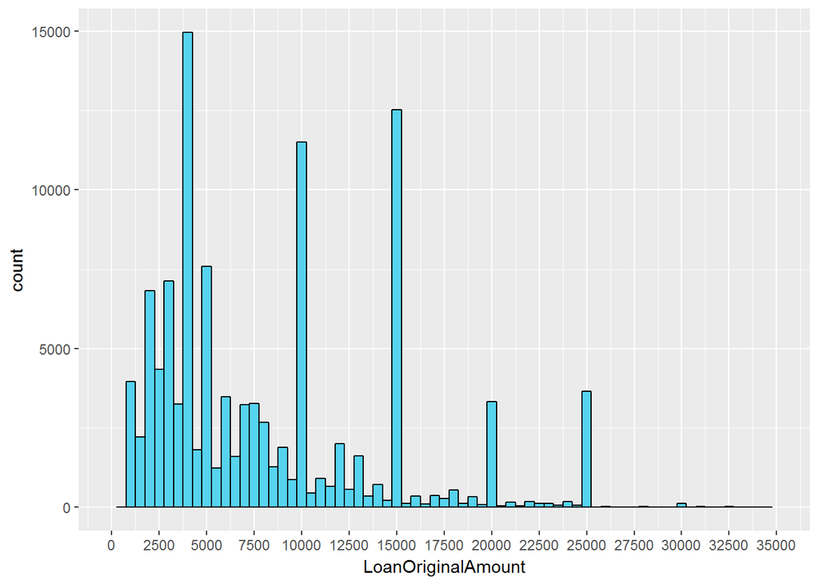

The histogram for loan amounts appears to be a right skewed distribution. There are however large spikes at prices that are factors of 5 and 10 thousand. The most noticeable of these spikes are at the 10,000 and 15,000 loan amounts. These spikes are likely attributed to people simply “rounding up” their required amount to the nearest $5000. Additionally it could be because there are some default amounts listed (every $5k) and people just click these rather than enter their own number. Most of the loans are below 15,000 and interestingly our mode appears to be $4000. This seems odd given that we have spikes at loan amounts that are factors of 5 and 10.

During the sub-prime crisis and resulting GFC, many people used credit to help fuel their investment/improvement of real estate holdings in the hopes of flipping it for profit to the next person. As this dataset encompasses the years of the GFC, I was curious if people who owned a home had different borrowing patterns than those who didn’t.

## Loan Amount Distributions for Home Owners and Non-Home Owners

```
## False  True
## 56459 57478
```

The distribution of home owners to non-home owners is surprisingly fairly even with 56,459 non-home owners to 57,478 home-owners.

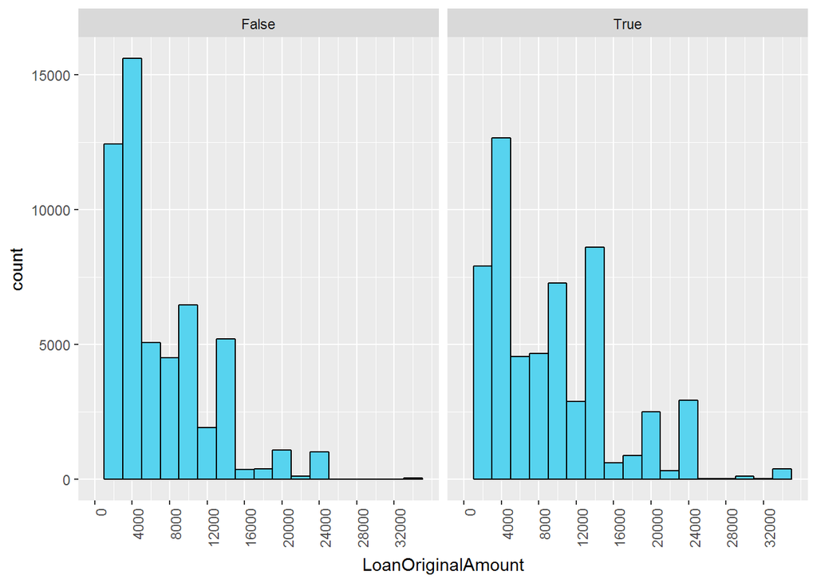

The above visual shows the two histograms for those are not home owners and those that are. It would appear that non-home owners actually had higher counts in the lower loan amount values (lower than 8k), whereas home-owners had higher counts of the higher loans values (8k and above).

## Loan categories

```
##      Not Available Debt Consolidation   Home Improvement
##              16965              58308               7433
##           Business      Personal Loan        Student Use
##               7189               2395                756
##               Auto              Other    Baby & Adoption
##               2572              10494                199
##               Boat Cosmetic Procedure    Engagement Ring
##                 85                 91                217
##        Green Loans Household Expenses    Large Purchases
##                 59               1996                876
##     Medical/Dental         Motorcycle                 RV
##               1522                304                 52
##              Taxes           Vacation       Wedding Loan
##                885                768                771
```

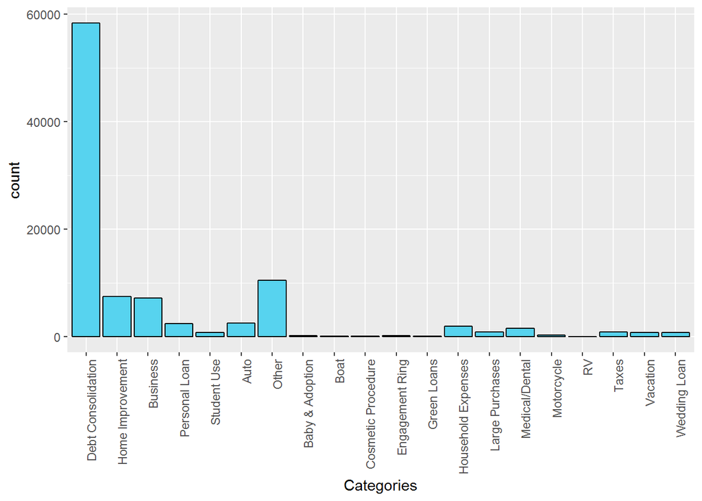

## Borrower Occupations

We should also take a quick look at the occupations of borrowers.

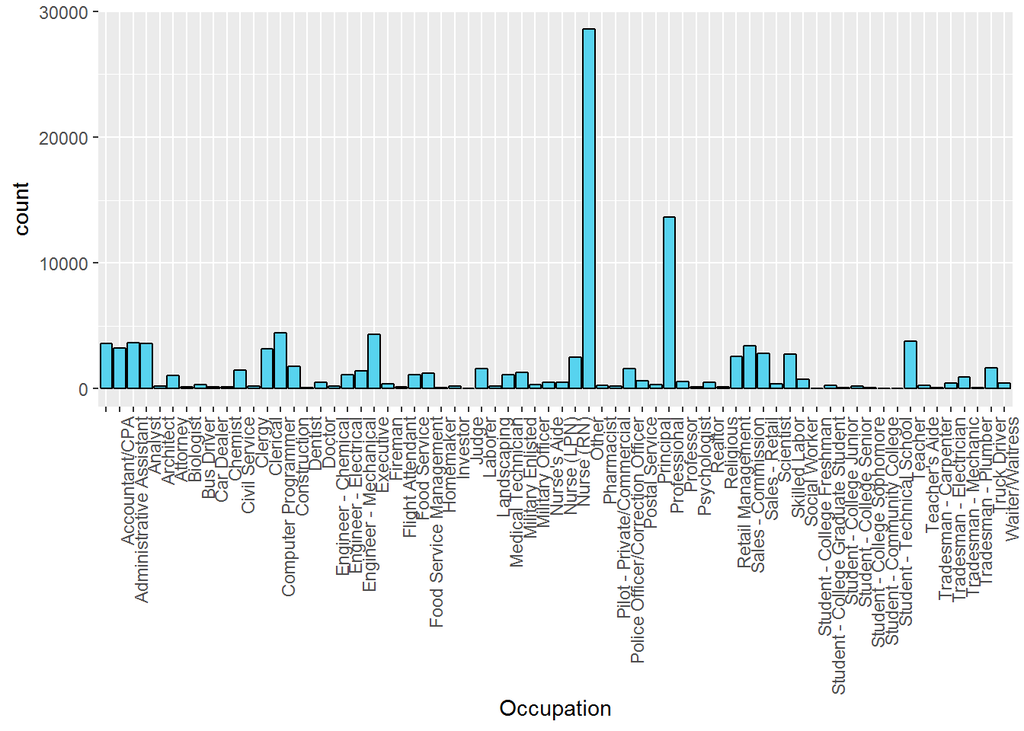

The above visual is a little less revealing than I had hoped it be. There is two obvious spikes, being “Other” and “Professional”. They are both very nondescript and eludes to the possibility that many borrowers are hesitant on adding their actual profession to their loan request. Instead we shall take a look at their employment status.

## Employment Status

```
##                    Employed     Full-time Not available  Not employed
##          2255         67322         26355          5347           835
##         Other     Part-time       Retired Self-employed
##          3806          1088           795          6134
```

There are 8 categories of employment. The highest being simply “Employed” at 67,322. It is unfortunate these individuals aren’t categorised into what form of “Employed” they are.

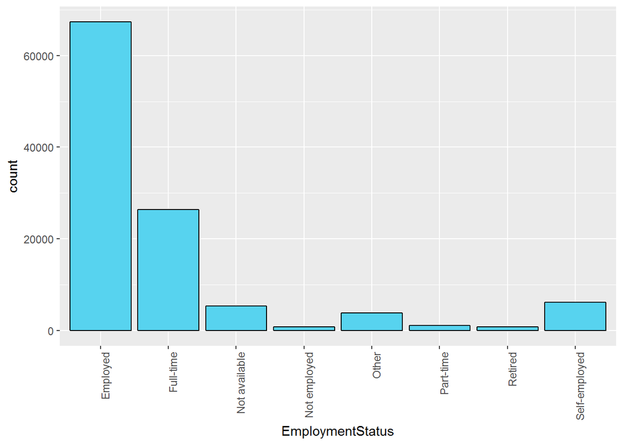

Employment status tells us some information, however it is still a little underwhelming. “Employed” has the highest spike, yet it doesn’t tell us if these people are full time, part time, casual or self employed. One has to wonder whether these sub-par financial assessments are linked to delinquincy. We will examine this later. Other than the nondescript “Employed” spike, the next largest group appears to be full time employment, followed by self employed.

As we have been unable to gather any strong signal using the employment status and occupation variables, we can try examining borrower income levels.

## Income Range

```
##             $0      $1-24,999      $100,000+ $25,000-49,999 $50,000-74,999
##            621           7274          17337          32192          31050
## $75,000-99,999  Not displayed   Not employed
##          16916           7741            806
```

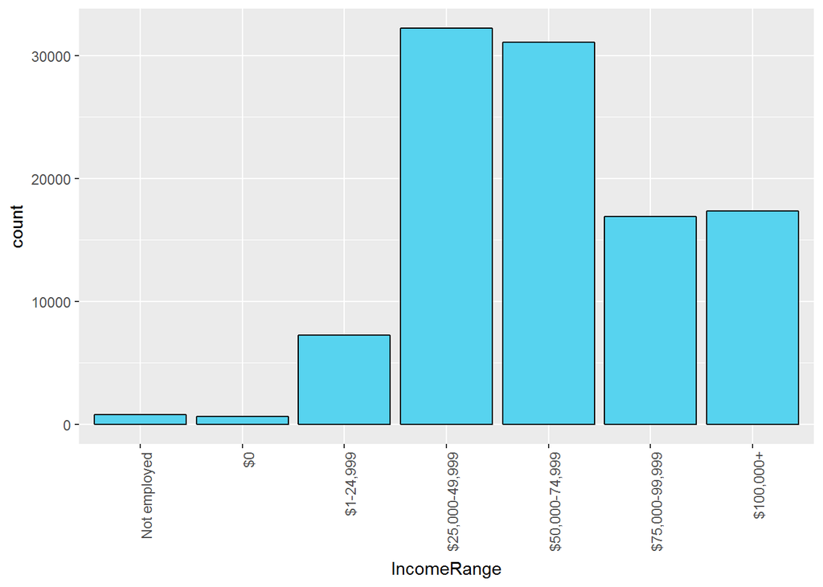

I adjusted the above graph to remove the “not displayed” entries and then placed the x-axis in logical order. It appears that the counts for middle income earners are the highest. Interestingly those in the upper income brackets have a higher count than those in the lower.

## Debt to income Ratio

```
##    Min. 1st Qu.  Median    Mean 3rd Qu.    Max.    NA's
##   0.000   0.140   0.220   0.276   0.320  10.010    8554
```

The debt to income ratio ranges from 0 to an enormous 10. The median is 0.22 with the 75% of borrowers falling under 0.32. We will generate a histogram with an x limit of 1.0 as this represents debt = income situation. The maximum of 10 would represent a party that is either heavily in debt or leveraged to the hilt on an investment.

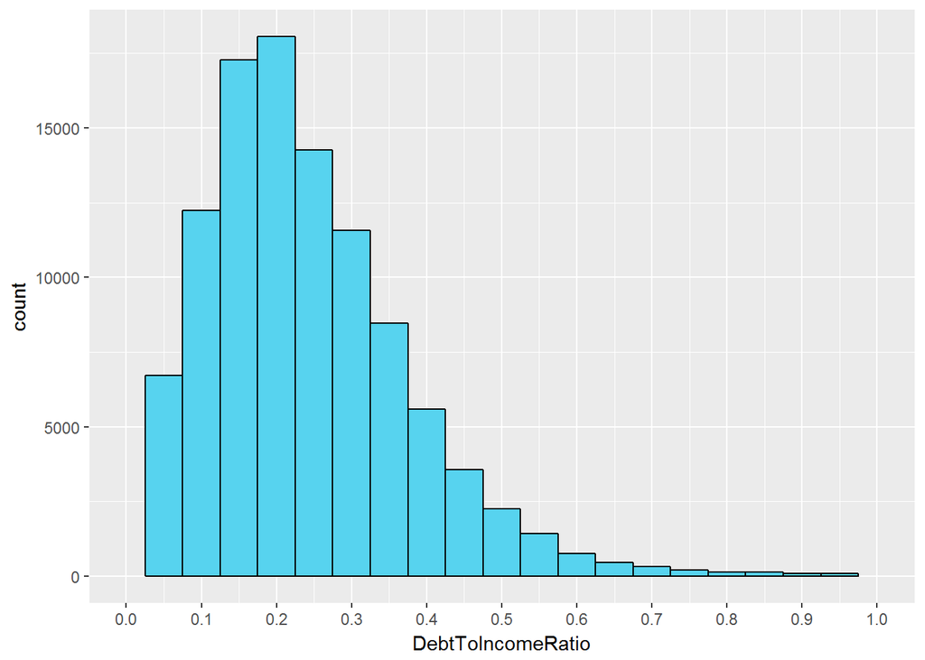

The debt to income ratio histogram is actually quite a nice visual. I limited the x-axis to a D:I ratio of 1.0 (debt=income), however there are instances of borrowers which are beyond this point. The bulk of borrowers have a D:I between 0.05 and 0.4.). A D:I of 0.4 is around the maximum for borrowers seeking a a more stable qualified mortgage and both the median and mean fall below this.

## Current Credit Lines

```
##    Min. 1st Qu.  Median    Mean 3rd Qu.    Max.    NA's
##    0.00    7.00   10.00   10.32   13.00   59.00    7604
```

The average is about 10, however the max is quite a large 59. 75% of borrowers have less than 13 current lines of credit.

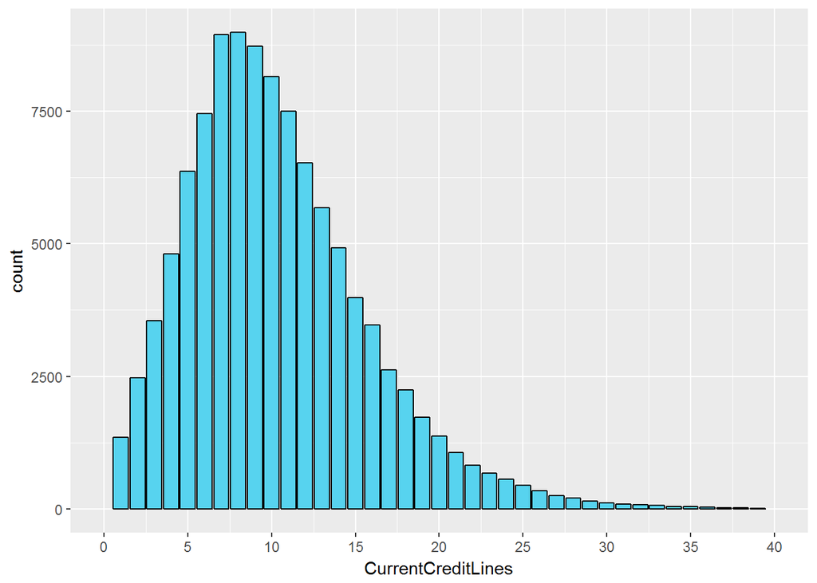

The histogram of current credit lines is skewed right and centered around 7.5.

## Employment Status Duration

```
##    Min. 1st Qu.  Median    Mean 3rd Qu.    Max.    NA's
##   0.000   2.167   5.583   8.006  11.417  62.917    7625
```

The duration of employment variable is in months so I have divided it by 12 to convert it to years. We find that the median is about 5.5 with most of the borrowers having been employed for less than 11.5 years. This would make sense given that an online p2p loan platform would appeal to younger generations over older ones. The max is 62.9 years which is quite an outlier.

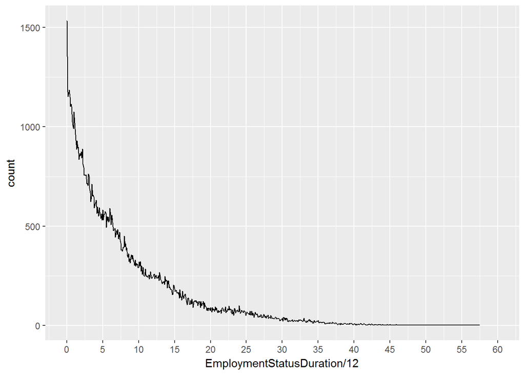

As expected employment status duration is skewed right. From the line and the summary above we can gather that 50% of borrowers had been employed for less than 6 years. The average time was 8 years and the max was a surprising 63. Another interesting thing is that our first quartile is sitting at 2.2, so 25% of people have less than 2.2 years employment. I do wonder if this is simply because of age or possibly because of the inability to find employment.

## Credit Scores

```
##    Min. 1st Qu.  Median    Mean 3rd Qu.    Max.    NA's
##   1.000   3.000   4.000   4.072   5.000   7.000   29084
```

Our average and median are about 4 which corresponds to a C rating.

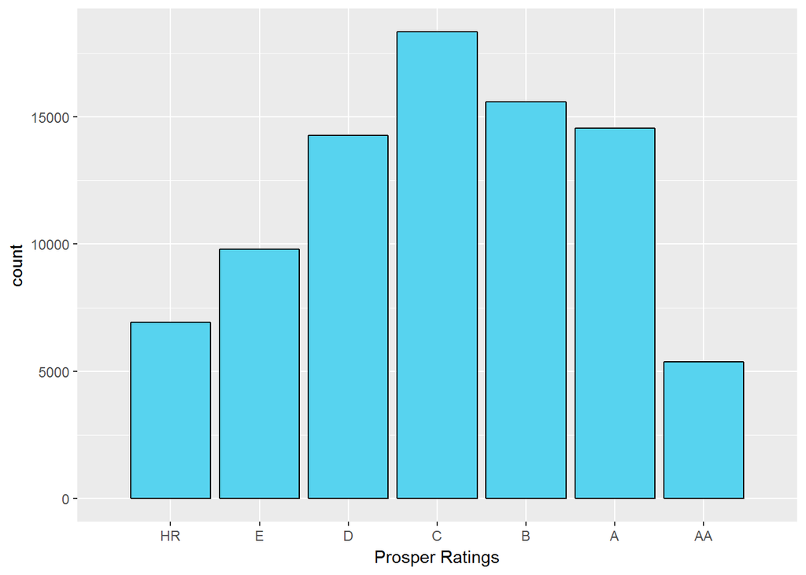

The above visual shows the counts of the different loan ratings from high risk (HR) to safe AA grade. The plot has a fairly normal distribution and the mean and median are about a C rating. It would be interesting to see the distribution of these ratings over time.

## Average Credit Rating

```
##    Min. 1st Qu.  Median    Mean 3rd Qu.    Max.    NA's
##     9.5   669.5   689.5   695.1   729.5   889.5     591
```

The average credit score is around 690. This is actually better than I had imagined it would be. The minimum is an abysmal 9.5 and the max is 890. It is a little concerning that 75% of borrowers are below 730, barely scraping in to the satisfactory zone.

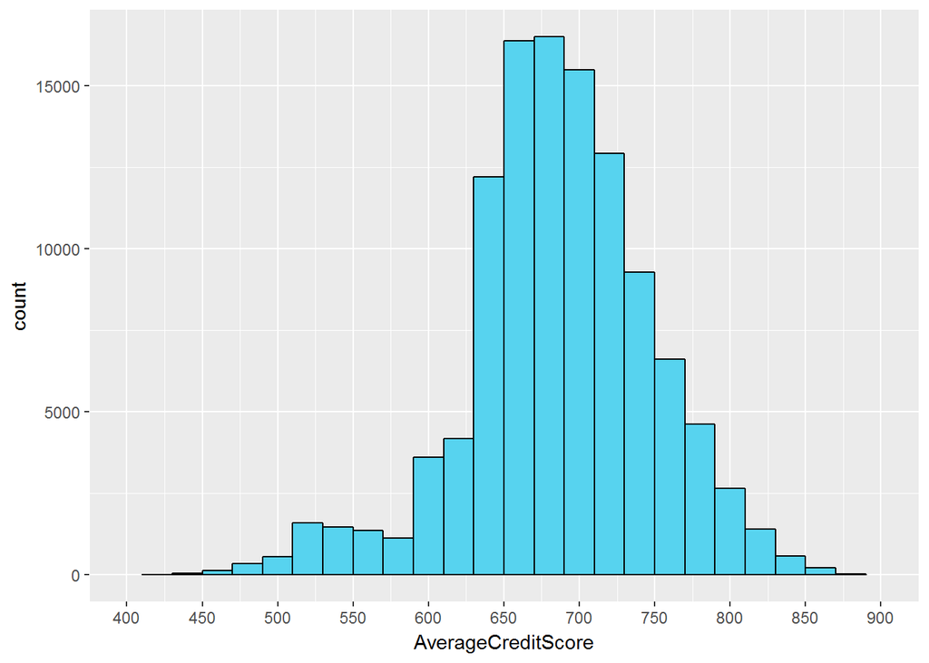

Average credit score has a relatively normal distribution centered around 650-700.

## Borrower APR

```
##    Min. 1st Qu.  Median    Mean 3rd Qu.    Max.    NA's
## 0.00653 0.15629 0.20976 0.21883 0.28381 0.51229      25
```

Median and mean are around the 20 - 22% mark. The lowest is 0.6% and the highest is 51.2%. The third quartile is around the 28% mark.

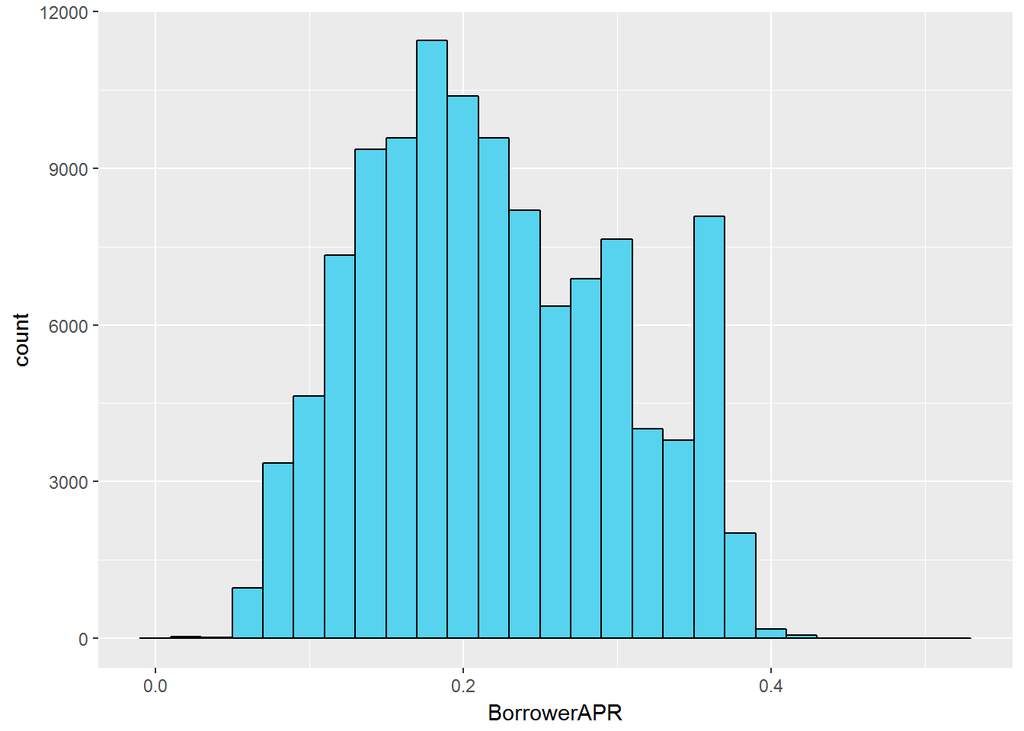

Relatively normal distribution of APR centered around the 0.20 mark.There is a a spike at the 0.36 mark. I’m not quite sure what that could be.

## Credit Score Bins

We will create a new variable that will hold binned valued for a borrowers average credit score. These bins are associated average credit scores are as follows -

Very Unsatisfactory (<560) Unsatisfactory (560 - 719) Satisfactory (720 - 879) Good (880 - 959) Excellent (960 - 1000)

```
##                Good        Satisfactory      Unsatisfactory
##                  27               38252               70784
## Very Unsatisfactory                NA's
##                4283                 591
```

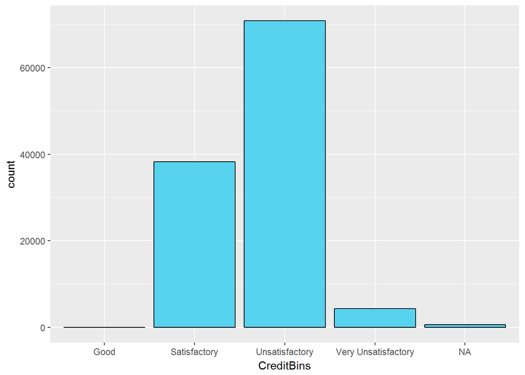

As we can see the Unsatisfactory group has the highest count with over 70k. The next highest is Satisfactory at 38k. There is only 27 borrowers with a credit rating over 880. This is actually not surprising as those with sub-par credit ratings would be drawn to this sort of p2p loan facility.

# Univariate Analysis Summary

### What is the structure of your dataset?

Using Univariate analysis we were able to get a feel for the dataset. It is rather robust at 81 variables. One major issue is that some of the variables have generalised answers where borrowers have declined to provide information, or have given a nondescript answer.

### What is/are the main feature(s) of interest in your dataset?

Examining this dataset completely would be far beyond the scope of this project. Instead I will focus on some of the above variables and their relationship with each other. I would like to see if there were changes to lending and delinquency patterns just prior to the GFC.

### What other features in the dataset do you think will help support your investigation into your feature(s) of interest?

Described above.

### Of the features you investigated, were there any unusual distributions? Did you perform any operations on the data to tidy, adjust, or change the form of the data? If so, why did you do this?

Described above.

# Bivariate Plots

We will now look at our variables in a little more detail and begin to analyse the relationships between them. As this dataset is all about loans, we will start by taking a look at loan amounts over time.

## Loan Size Distribution Over Time.

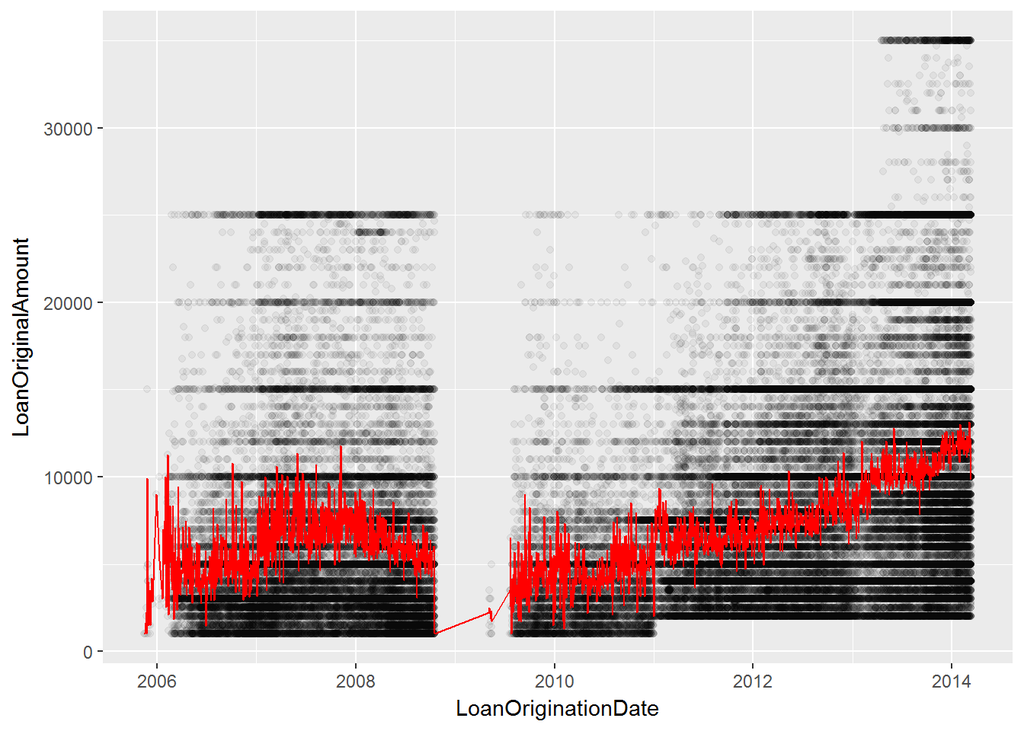

While the above visual is heavily overplotted a few major things stand out.

It appears that between late 2008 and mid 2009 very few new loans seem to be created. After some research online I found that the reason for this is that in October 2008 Propser decided to stop all new lending on it’s site because of scrutiny by the SEC. Prosper then announced in late April 2009 that it reopen it’s lending platform in california (seen as the faint spike in loans at the center of the gap in the above visual). Finally in July it began brokering in 46 states again which is where the gap in the visual above ends.

Another thing that stands out is the emphasised horizontal price lines at the $5k intervals. It is likely that people simply rounded up to the nearest $5k when selecting their desired loan amount.

The mean line in red also shows a rise during the peak of the sub-prime mortgage crisis. Is it possible that some of the loans through Prosper were also sub-prime?

One final observation is that at about the end of the first quarter of 2013 it appears that Prosper may have increased their maximum loan limit as we see the emergence of loans that exceed $25k.

## Loan amounts for each loan category.

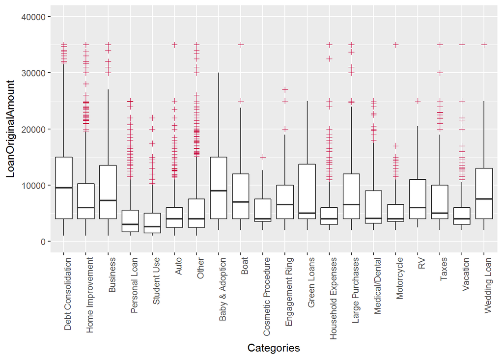

We can see that debt consolidation and baby/adoption categories have the largest loan amounts. This result for debt consolidation was expected, however the baby/adoption category having loans this large was a surprise. Other categories that have high loan amounts include business, green loans and wedding loans.

## Delinquencies per Quarter

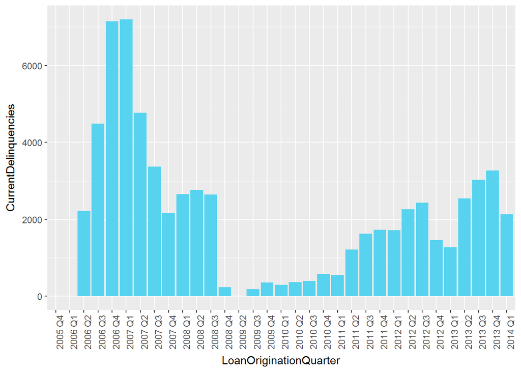

The above bar graph is quite interesting. We see a big spike in current delinquencies in the second half of 2006 and first half of 2007. The GFC is commonly believed to have begun in July 2007. It was set off by a speculative credit fueled housing bubble. Could this spike be an indicator that some families were running out of money and were unable to service their loans?

## Average Quarterly Credit Score

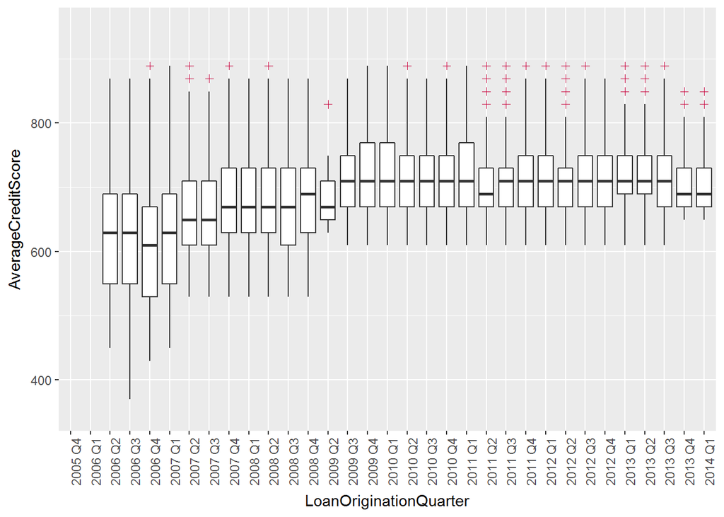

The above plot shows that pre GFC there were quite a number of borrowers with poor credit scores. Anything below about 650 can be considered a less than ideal credit score. In fact the median for these years appears to be less than the standard “good score” of 700. It appears that when the company re-opened to all states in 2009, they also implemented some new rules for minimum credit scores. It can be see that beginning in Q3 2009, the median is a little over 700 and the lower extreme does not dip below 600. Could this possibly show that credit providers did make some changes following the GFC?

## Credit lines by Income Range

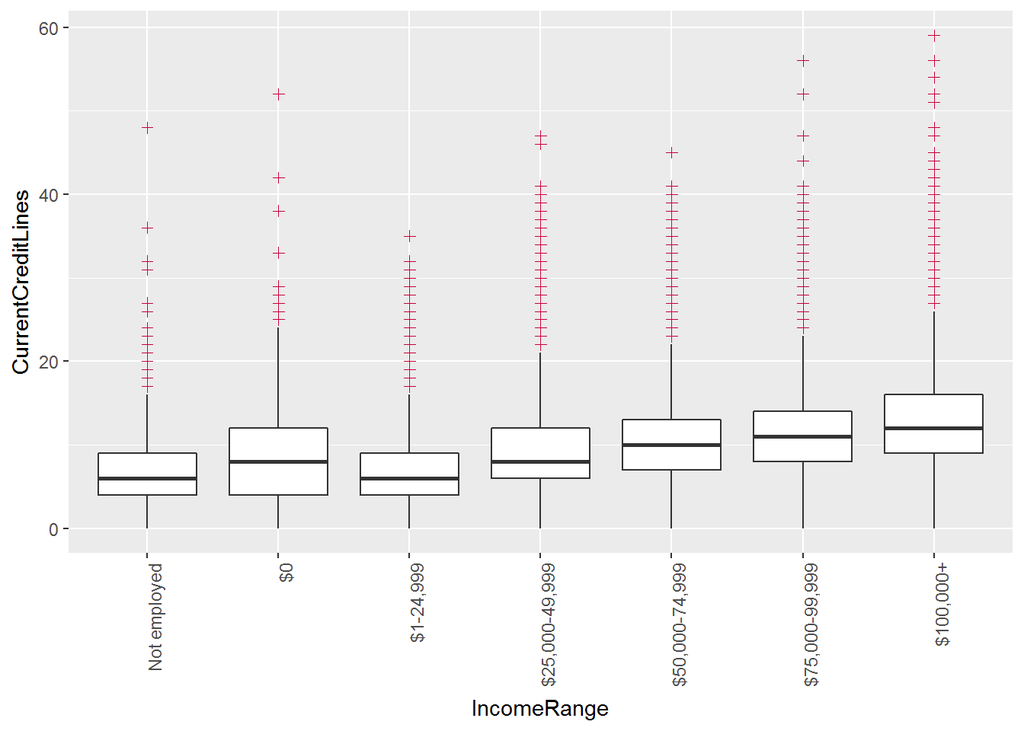

Median current credit lines appears to increase as income rises. This trend does not hold for those with an income of 0. The IQR for those with $0 income is the largest of all the groups.

## Employment Length and Loan Status

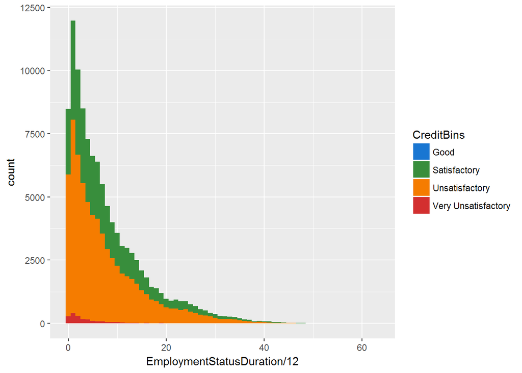

We can see that the portion of borrowers with very unsatisfactory credit scores are fairly concentrated in the lower employment duration area. Most are under 5 years employment duration. Could this be because many of these individuals are jumping between part-time jobs and are sometimes unable to service their credit, leading to the bad credit scores?

Unsatisfactory level retains a higher count than satisfactory for most of the graph and this is to be expected given this service would likely attract those who are unable to get a suitable interest rate when applying for a loan at a financial institution such as a bank.

## Borrower APR to Credit Rating

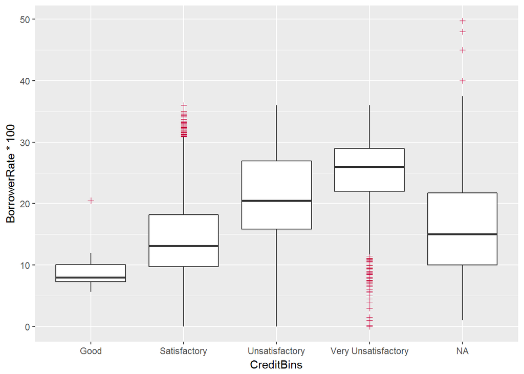

As we can see in the above visual, the borrower rate is somewhat negatively correlated with credit score. The median for “good” credit scores is less than 10% and the median for “very unsatisfactory” appears to be a little over 26%. The NA values have a median of about 15, placing them in the risk area somewhere between satisfactory and unsatisfactory.

# Bivariate Analysis

### Talk about some of the relationships you observed in this part of the investigation. How did the feature(s) of interest vary with other features in the dataset?

Described above.

### Did you observe any interesting relationships between the other features (not the main feature(s) of interest)?

Described above.

### What was the strongest relationship you found?

Strongest relationship would be the borrower rate and the credit score (bins)

# Multivariate Plots Section

## Quarterly Delinquencies by Income Range

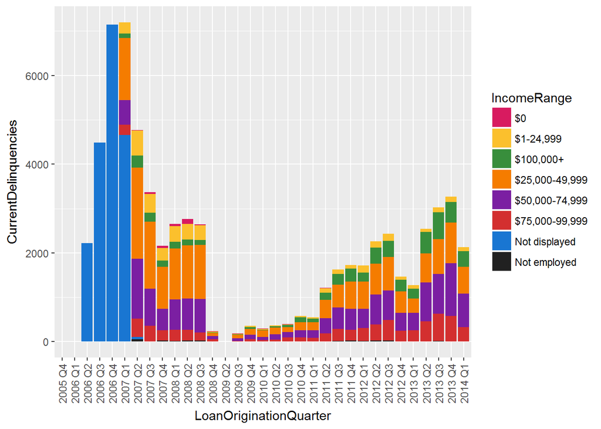

The above graph shows the distribution of current delinquencies for each income range across time. I had hoped it would reveal some information regarding the income range of delinquent borrowers in the lead up to the GFC, however it appears that the “Income range” application question was only introduced in the first few months of 2007. We can still see that most of the current delinquencies are from those in the 25 - 50k income range. Instead we might try using bin values for credit rating.

## Quarterly Delinquencies by Credit Bin

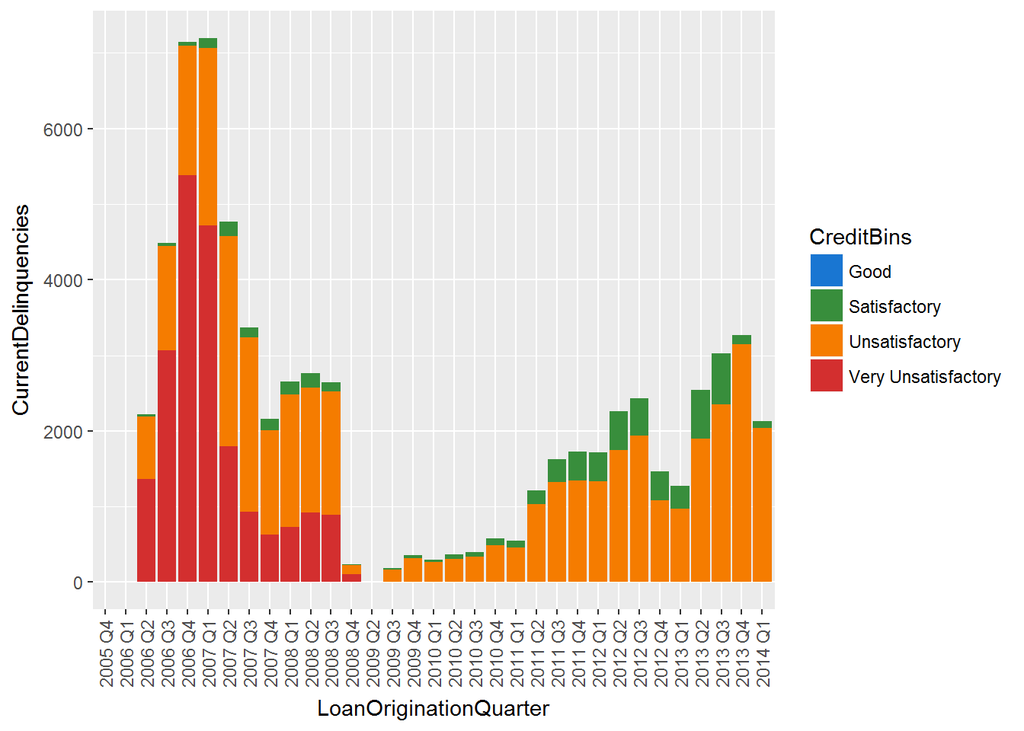

From the visual we can see that no borrowers with a “good” credit rating have any delinquencies and this is expected. Those with satisfactory make up a small portion of delinquencies. There were a large number of borrowers with very unsatisfactory credit ratings and current delinquencies in the lead up to the GFC. Credit ratings in the very unsatisfactory bin appear to disappear from 2009 and this actually lowers the current delinquencies count significantly.

## Delinquencies by Employment Status and Credit Score

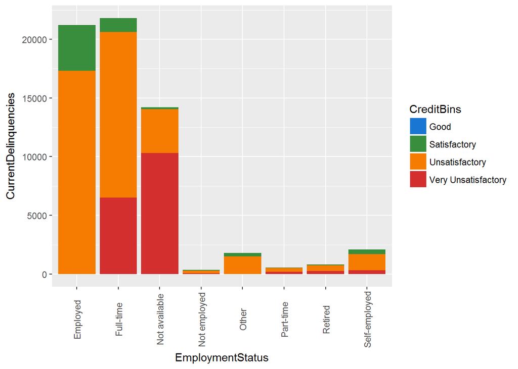

The above bar graph is simple but it does elude to a number of things. The first observation is that most groups contain some proportion of very unsatisfactory credit score borrowers (with the exception of “Employed”). The “Employed” category appears to have a higher proportion of borrowers with higher credit scores than the rest of the groups. The highest proportion of “Very Unsatisfactory credit score borrowers have come from the”Not Available" employment status group. This seems somewhat suspicious, as if those with bad credit scores are refraining from writing their employment status or lack there of.

## Credit Binned Quarterly Delinquencies by Employment Status

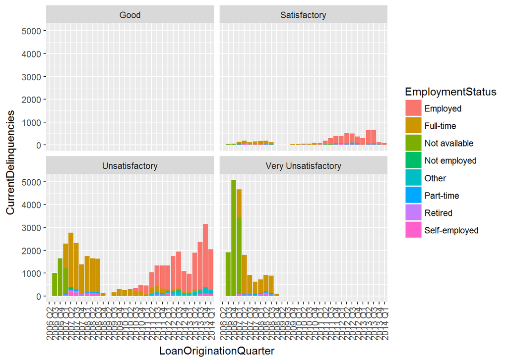

## Borrower APR vs Credit Score by Prosper Rating

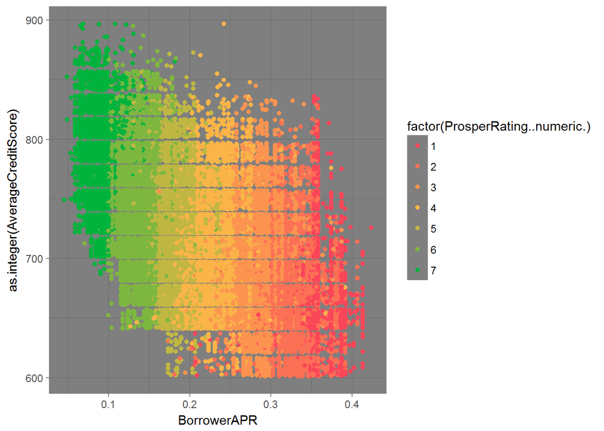

The above chart is quite detailed and there is a bit to digest. It shows the relationship between average credit score and borrower APR for each of the 7 prosper ratings. Further discussion on this will be in the next section.

# Multivariate Analysis

### Were there any interesting or surprising interactions between features?

Yes, they will be described in the next section

### OPTIONAL: Did you create any models with your dataset? Discuss the strengths and limitations of your model.

Given my current time constraints I did not create any models with the dataset. However I fully intend to at a later date.

# Final Polished Plots and Summary

### Plot One

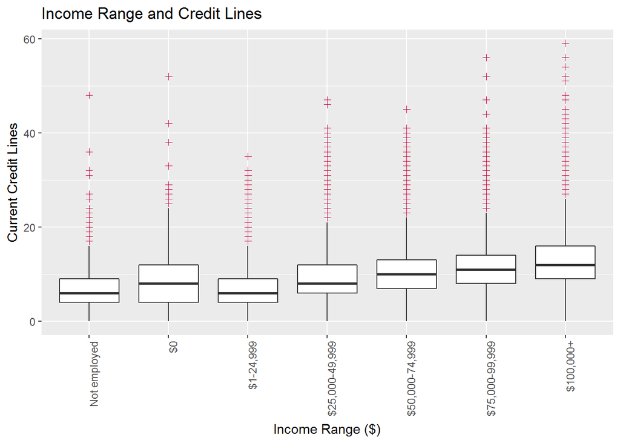

### Plot Two

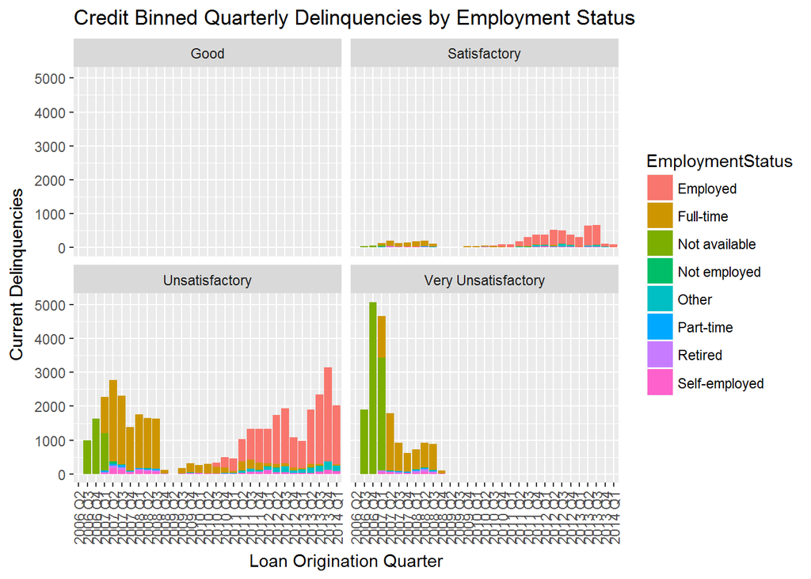

### Plot Three

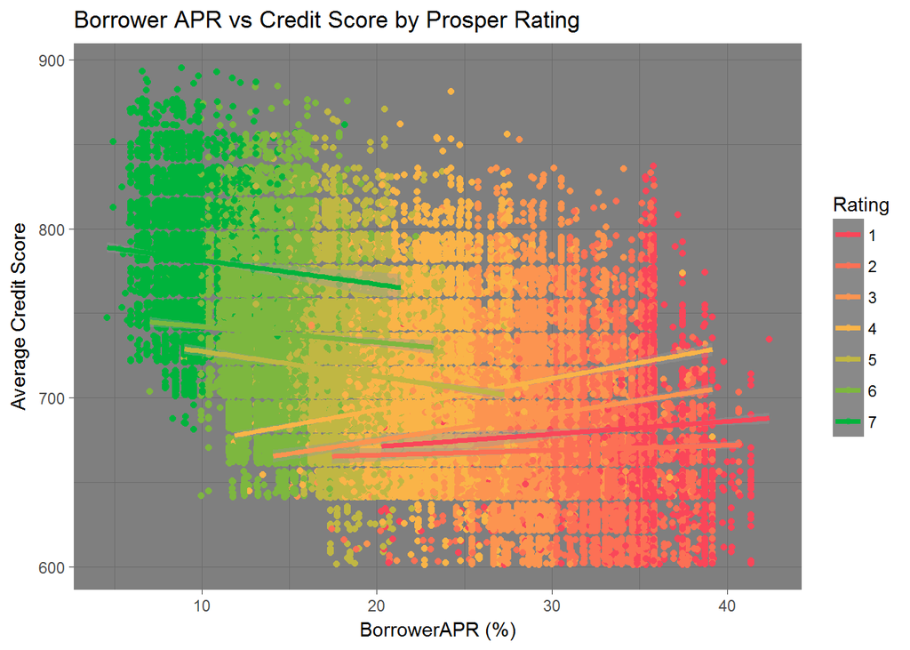

### Description Three

There is quite a bit to digest in this scatter plot. The first observation is that as credit score decreases, borrower APR increases (negative correlation). The second observation is that the ratings prosper applies to their loans appear to be fairly linked to the credit score and APR. We can see an almost rigid colored stepping pattern as we move to lower credit scores and higher APR. I have also added some lm lines so that we can see the trend lines for each of the ratings.

# Reflection

I am relatively new to R and as such this was a steep learning curve which I hope to improve on as I learn more. The dataset was somewhat challenging, not because of the length but because of the large amount of variables. I first had to spend some time looking at the excel variable file and deciding what I would examine before I even touched this report. A number of my charts were a little disappointing as there was a lot of non-specific data. Examples of this include the “Employed” category for employment and the lack of income range data pre-GFC.

Given the time constraints I had with balancing work with this project, I was unable to construct any models. Future work would include analysing the investing side of the data rather than just the debtor side. I would also like to construct a model to predict defaults.

# References

https://stackoverflow.com/questions/17496358/r-help-converting-factor-to-date

https://www.rstudio.com/wp-content/uploads/2015/03/ggplot2-cheatsheet.pdf